# Simple feed forward network with one hidden layer

# Classification with stacked autoencoder

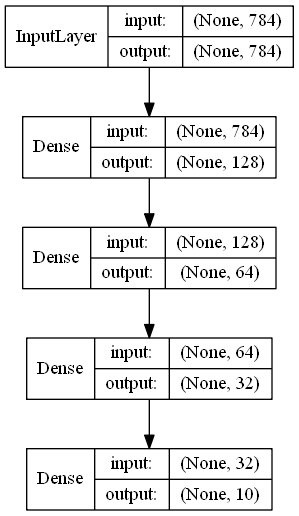

```python
Image('images/sae_classifier.png')
```

# Plot a two dimensional representation of the data

To get a good visible explanation of what an autoencoder is doing, we tried to distill the data down to only two dimensions; in hope to see a picture of our problem. Maybe a picture where an unsupervised learning technique like clustering might be able to classifiy most of the points correctly.

## Fourth layer

Adding an additional two dimensional classifying single autoencoder 32-2-32-10 to our previous SAE setup yields two interesting results:

1. even with only two dimensions we get a test accuracy of 0.968730016327
2. the figure below shows a good explanation of whats happening with the data.

For this last layer we used sigmoid activation instead of relu. This would not change much in our classification result but the information is more uniform spread in the [0,1]x[0,1] square. So it gives a better view but does not make much difference for the machine.

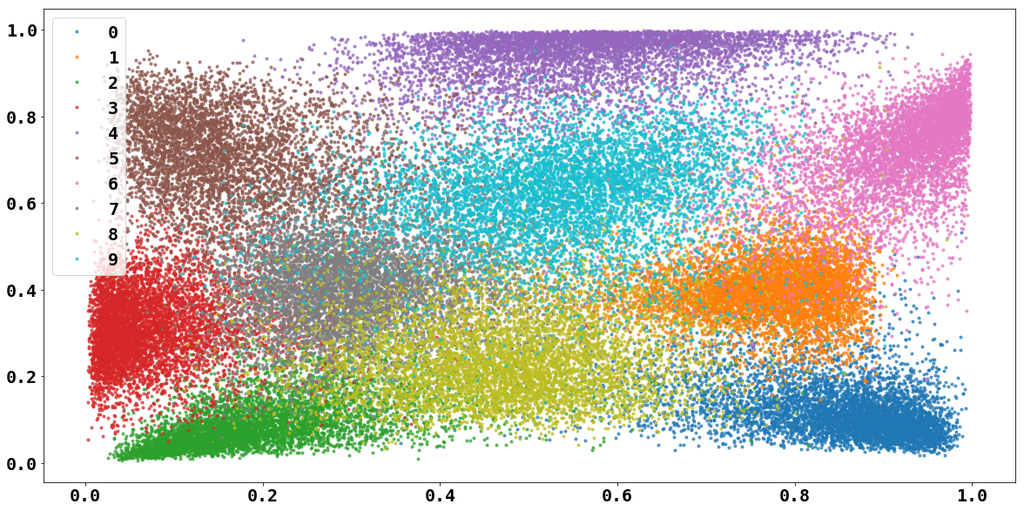

## Fourth layer directly accessed

Another idea would be to directly encode all the data into a two- dim layer like. 784-2-784-10 single autoencoder. Interesteingly this yield the exact same accuracy 0.968730016327 on the testset than the more granulated compression mentioned above (784-128-64....). But: the distribution of the data in the unit square is not as uniform. So we conclude, that a stacked autoencoder reduces dimension in a more uniform way than a non- stacked autoencoder.

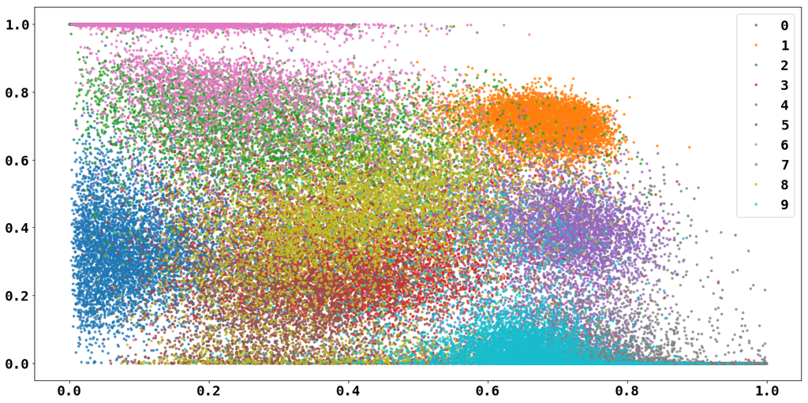